# Data Visualization: Clothing

Gita

2022-06-29

# Background

```r
# Membersihkan environment
rm(list = ls())
# chunk options
knitr::opts_chunk$set(
  message = FALSE,
  warning = FALSE,
  fig.align = "center",
  comment = "#>"
)
# scientific notation
options(scipen = 9999)
```

## Input Data

Pastikan data yang ingin dipakai sudah satu folder dengan R project

```r
# membaca data
clothing <- read.csv("data_input/clothing.csv")
```

**Data sudah siap digunakan dan bisa dilanjutkan ke tahapan selanjutnya**

# Data Inspection

```r
# cek 5 data teratas
head(clothing)
```

```
#>   clothing_id age_group rating recommended_ind positive_feedback_count
#> 1         767  25 to 34      4               1                       0
#> 2        1080  25 to 34      5               1                       4
#> 3        1077  55 to 64      3               0                       0
#> 4        1049  35 to 54      5               1                       0
#> 5         847  35 to 54      5               1                       6
#> 6        1080  35 to 54      2               0                       4
#>    division_name category review_date
#> 1      Initmates Intimate  30/03/2017
#> 2        General  Dresses   10/3/2017
#> 3        General  Dresses    4/3/2017
#> 4 General Petite  Bottoms    3/3/2017
#> 5        General     Tops  14/12/2017
#> 6        General  Dresses    8/9/2017
```

```r
# cek 5 data terbawah
tail(clothing)
```

```
#>       clothing_id age_group rating recommended_ind positive_feedback_count
#> 23481         862  35 to 54      5               1                       0
#> 23482        1104  25 to 34      5               1                       0
#> 23483         862  35 to 54      3               1                       0
#> 23484        1104  25 to 34      3               0                       1
#> 23485        1084  25 to 34      3               1                       2
#> 23486        1104  35 to 54      5               1                      22
#>        division_name category review_date
#> 23481 General Petite     Tops  26/05/2018
#> 23482 General Petite  Dresses  26/05/2018
#> 23483 General Petite     Tops  26/05/2018
#> 23484 General Petite  Dresses  26/05/2018
#> 23485        General  Dresses  26/05/2018
#> 23486 General Petite  Dresses  26/05/2018
```

```r
# cek bentuk dari data
dim(clothing)
```

```
#> [1] 23486     8
```

```r
# cek data NA
colSums(is.na(clothing))
```

```
#>             clothing_id               age_group                  rating
#>                       0                       0                       0
#>         recommended_ind positive_feedback_count           division_name
#>                       0                       0                      14
#>                category             review_date
#>                      14                       0
```

Cek untuk missing value

```r
# menghilangkan missing data
# import library
library(tidyverse)
clothing <- clothing %>%
  drop_na(division_name, category)
colSums(is.na(clothing))
```

```
#>             clothing_id               age_group                  rating
#>                       0                       0                       0
#>         recommended_ind positive_feedback_count           division_name
#>                       0                       0                       0
#>                category             review_date
#>                       0                       0
```

```r
# deskripsikan nama column
names(clothing)
```

```
#> [1] "clothing_id"             "age_group"
#> [3] "rating"                  "recommended_ind"
#> [5] "positive_feedback_count" "division_name"
#> [7] "category"                "review_date"
```

# Data Cleansing and Coertions

Cek tipe data untuk setiap column

```r
str(clothing)
```

```
#> 'data.frame':    23472 obs. of  8 variables:
#>  $ clothing_id            : int  767 1080 1077 1049 847 1080 858 858 1077 1077 ...
#>  $ age_group              : chr  "25 to 34" "25 to 34" "55 to 64" "35 to 54" ...
#>  $ rating                 : int  4 5 3 5 5 2 5 4 5 5 ...
#>  $ recommended_ind        : int  1 1 0 1 1 0 1 1 1 1 ...
#>  $ positive_feedback_count: int  0 4 0 0 6 4 1 4 0 0 ...
#>  $ division_name          : chr  "Initmates" "General" "General" "General Petite" ...
#>  $ category               : chr  "Intimate" "Dresses" "Dresses" "Bottoms" ...
#>  $ review_date            : chr  "30/03/2017" "10/3/2017" "4/3/2017" "3/3/2017" ...
```

** Berdasarkan hasil tersebut, ditemukan beberapa tipe data yang tidak tepat. Sehingga diperlukan perubahan tipe data (data coertion)**

```r
# change data type
clothing$review_date <- as.Date(clothing$review_date, "%y/%m/%d")
clothing$age_group <- as.character(clothing$age_group)
clothing$positive_feedback_count <- as.numeric(clothing$positive_feedback_count)
str(clothing)
```

```
#> 'data.frame':    23472 obs. of  8 variables:
#>  $ clothing_id            : int  767 1080 1077 1049 847 1080 858 858 1077 1077 ...
#>  $ age_group              : chr  "25 to 34" "25 to 34" "55 to 64" "35 to 54" ...
#>  $ rating                 : int  4 5 3 5 5 2 5 4 5 5 ...
#>  $ recommended_ind        : int  1 1 0 1 1 0 1 1 1 1 ...
#>  $ positive_feedback_count: num  0 4 0 0 6 4 1 4 0 0 ...
#>  $ division_name          : chr  "Initmates" "General" "General" "General Petite" ...
#>  $ category               : chr  "Intimate" "Dresses" "Dresses" "Bottoms" ...
#>  $ review_date            : Date, format: "2030-03-20" "2010-03-20" ...
```

# Data Explanation

```r
summary(clothing)
```

```
#>   clothing_id      age_group             rating      recommended_ind
#>  Min.   :   0.0   Length:23472       Min.   :1.000   Min.   :0.0000
#>  1st Qu.: 861.0   Class :character   1st Qu.:4.000   1st Qu.:1.0000
#>  Median : 936.0   Mode  :character   Median :5.000   Median :1.0000
#>  Mean   : 918.5                      Mean   :4.196   Mean   :0.8223
#>  3rd Qu.:1078.0                      3rd Qu.:5.000   3rd Qu.:1.0000
#>  Max.   :1205.0                      Max.   :5.000   Max.   :1.0000
#>  positive_feedback_count division_name        category
#>  Min.   :  0.000         Length:23472       Length:23472
#>  1st Qu.:  0.000         Class :character   Class :character
#>  Median :  1.000         Mode  :character   Mode  :character
#>  Mean   :  2.537
#>  3rd Qu.:  3.000
#>  Max.   :122.000
#>   review_date
#>  Min.   :2001-04-20
#>  1st Qu.:2006-12-20
#>  Median :2016-11-20
#>  Mean   :2016-02-02
#>  3rd Qu.:2025-11-20
#>  Max.   :2031-10-20
```

# Data Manipulation and Transformation

**periksa outlier dalam positive feedback count**

```r
aggregate(positive_feedback_count~category, clothing, mean)
```

```
#>   category positive_feedback_count
#> 1  Bottoms                2.117136
#> 2  Dresses                3.087514
#> 3 Intimate                1.887608
#> 4  Jackets                2.825581
#> 5     Tops                2.427111
#> 6    Trend                3.369748
```

```r
aggregate(positive_feedback_count~category, clothing, var)
```

```
#>   category positive_feedback_count
#> 1  Bottoms                17.06711
#> 2  Dresses                51.18022
#> 3 Intimate                14.75610
#> 4  Jackets                48.46227
#> 5     Tops                28.03835
#> 6    Trend                23.03162
```

```r
aggregate(positive_feedback_count~category, clothing, sd)
```

```
#>   category positive_feedback_count
#> 1  Bottoms                4.131236
#> 2  Dresses                7.154035
#> 3 Intimate                3.841367
#> 4  Jackets                6.961485
#> 5     Tops                5.295125
#> 6    Trend                4.799127
```

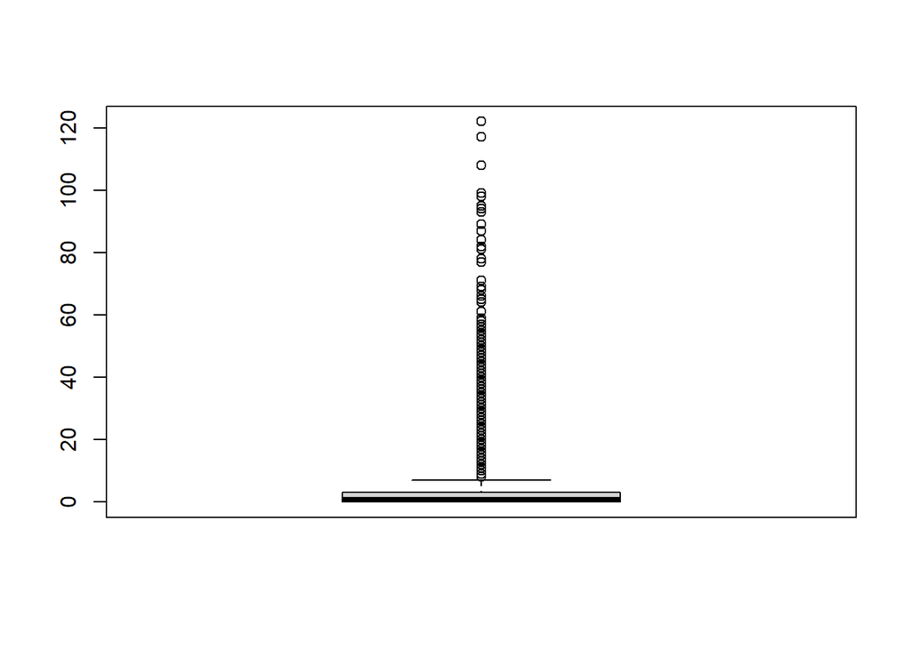

```r
boxplot(clothing$positive_feedback_count)
```

**Kesimpulan : Dari hasil di atas, kami menemukan kemungkinan adanya outlier, namun dari perhitungan kami, nilai Sd sekitar 6 (menurut saya masih bisa ditoleransi), jadi prosesnya bisa dilanjutkan**

Berapa total rating dari masing-masing kategori, dan mana yang tertinggi?

```r
aggregate(rating~category,clothing,sum)
```

```
#>   category rating
#> 1  Bottoms  16293
#> 2  Dresses  26229
#> 3 Intimate   7426
#> 4  Jackets   4401
#> 5     Tops  43675
#> 6    Trend    454
```

**Jawaban : rating tertinggi berasal dari kategori dari ‘tops’ di 43675 total rating**

Kategori mana yang memberikan angka penjualan terendah? berapa banyak keuntungan yang didapatkan?

```r
aggregate(rating~category,clothing,sum)
```

```
#>   category rating
#> 1  Bottoms  16293
#> 2  Dresses  26229
#> 3 Intimate   7426
#> 4  Jackets   4401
#> 5     Tops  43675
#> 6    Trend    454
```

**Jawaban : rating terendah berasal dari kategori dari ‘trend’ di 454 total rating**

`product category` mana berdasarkan based costumer `age_group` memberikan `positive_feedback_count` tertinggi?

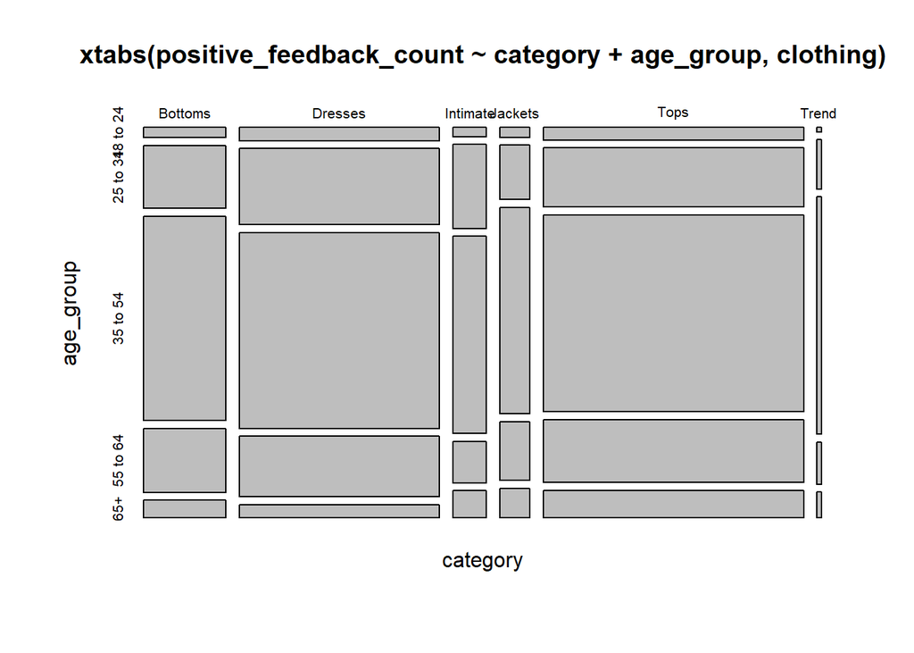

```r
plot(xtabs(positive_feedback_count~category + age_group,clothing))
```

**Jawaban : secara keseluruhan berdasarkan `age_group` `35 hingga 54` dan `positive feedback count` kategori `tops` adalah yang paling disukai konsumen**

Kategori mana berdasarkan division_name yang memberikan jumlah umpan balik paling positif?

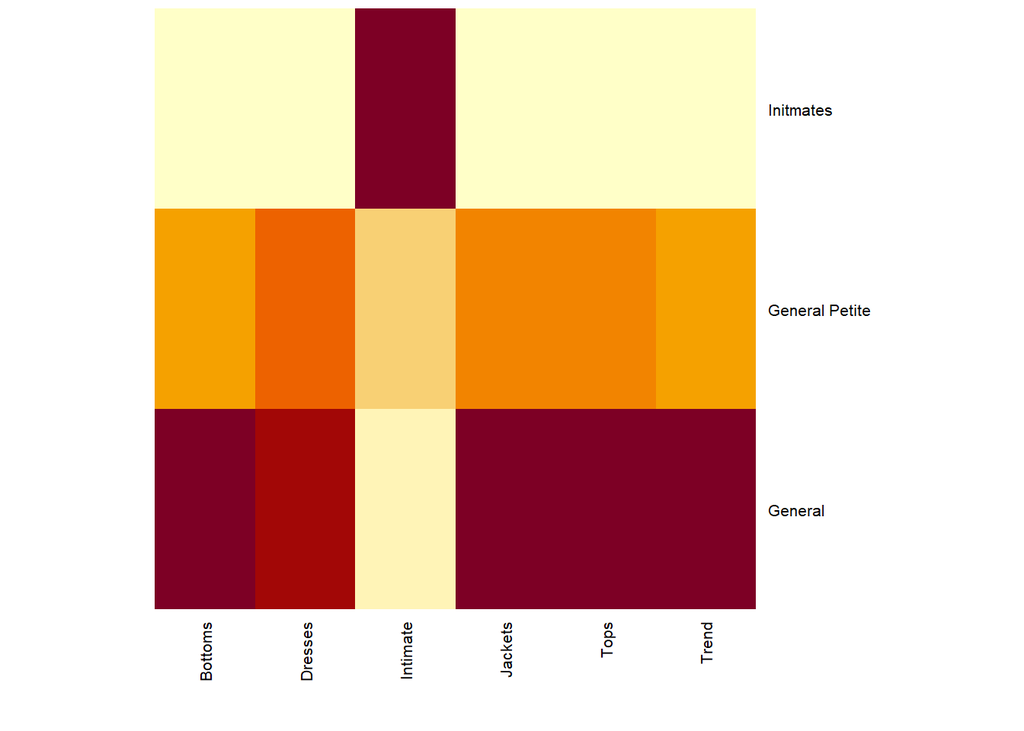

```r
heatmap(xtabs(positive_feedback_count~division_name+category, clothing), cexRow = 0.8, cexCol = 0.8, scale = "column", Colv = NA, Rowv = NA)
```

**Jawaban : Category of product yang paling disukai adalah `General`**

Pada bulan apa konsumen memberikan rating paling tinggi untuk kategori produk (based division_names)?

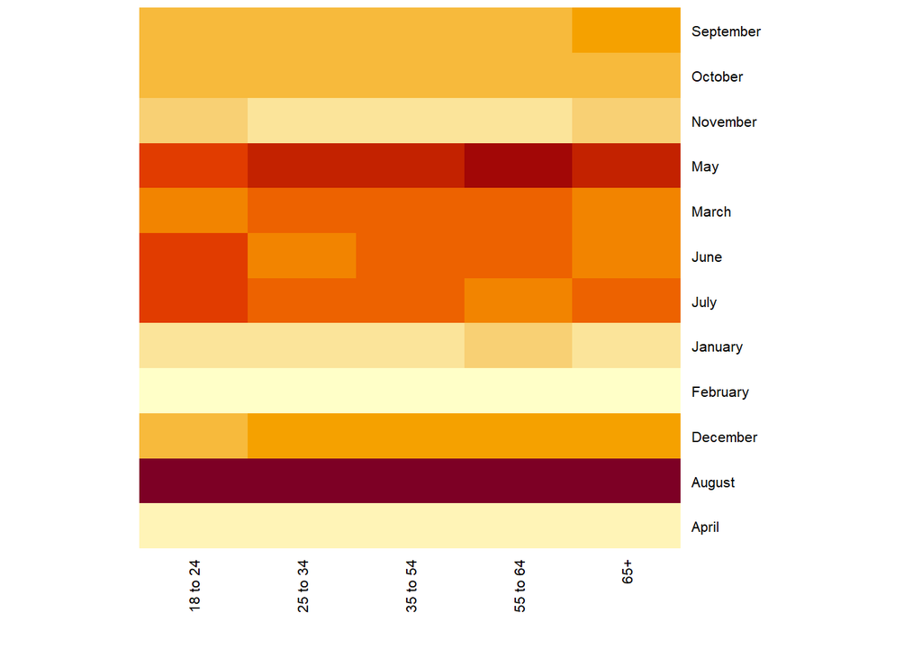

```r
# Membuat month column
clothing$review_month <- months(clothing$review_date)
# Membuat heatmap untuk visualisi data
heatmap(xtabs(rating  ~ review_month + age_group,clothing), cexRow = 0.8, cexCol = 0.8, scale = "column", Colv = NA, Rowv = NA)
```

**Jawaban : Konsumen paling banyak memberikan rating pada bulan `Agustus`**

Bagaimana aktivitas rating berdasarkan, product category and division_names ?

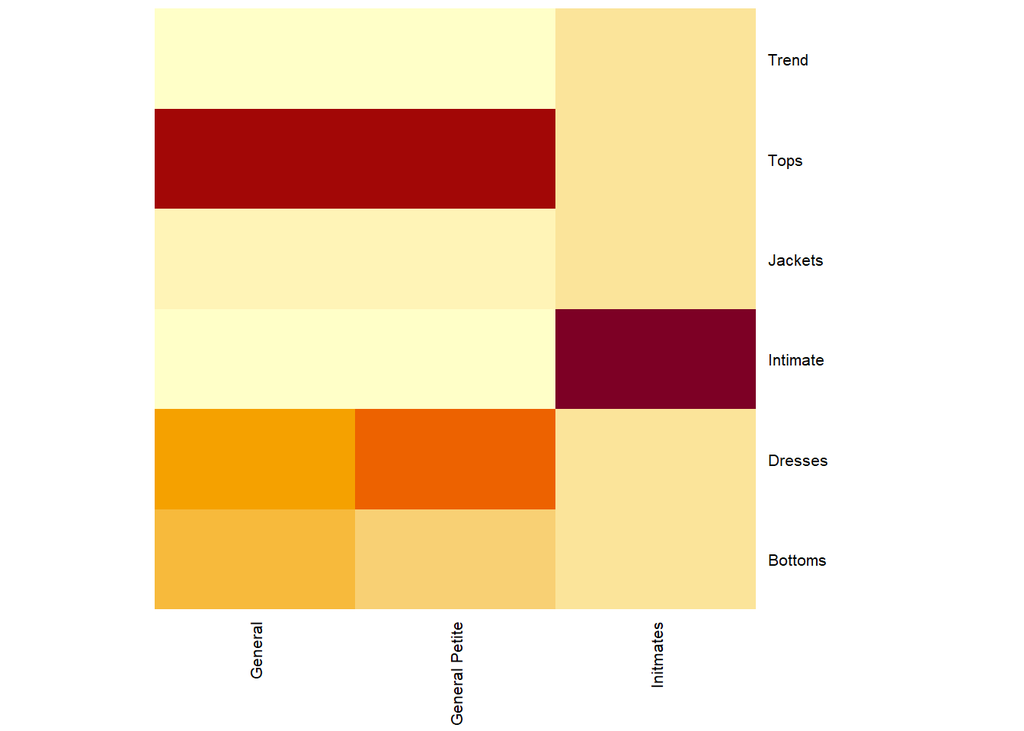

```r
# scale the consume rating
heatmap(xtabs(rating~category + division_name, clothing), cexRow = 0.8, cexCol = 0.8, scale = "column", Colv = NA, Rowv = NA)
```

**Jawaban : Rating tertinggi berdasarkan division_name dan category `General and General Petite` adalah `Tops` and for `Intimates` is `Intimate`**

Produk apa yang paling direkomendasikan berdasarkan consumer’s vote?

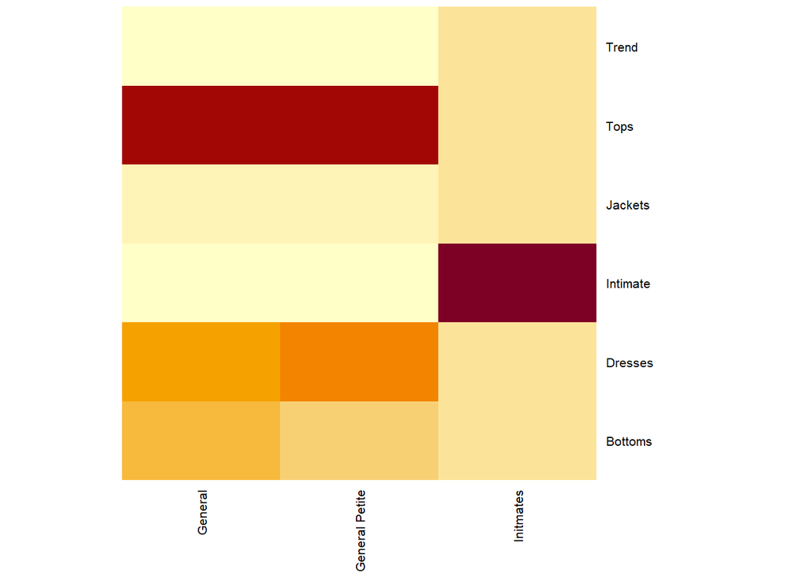

```r
# scale recommended product
heatmap(xtabs(recommended_ind ~ category + division_name, clothing), cexRow = 0.8, cexCol = 0.8, scale = "column", Colv = NA, Rowv = NA)
```

**Jawaban : Produk yang paling direkomendasikan berdasrkan division_name dan category `General and General Petite` adalah `Tops` and for `Intimates` is `Intimate`**

# Business Recomendation